# Psykometrisk utvärdering av PGSI-9

Magnus Johansson, Kristoffer Magnusson & Gustaf Reinebo  
*Workshop PGSI, Folkhälsomyndigheten, 2026-06-15*

Magnus Johansson, PhD

[Department of Clinical Neuroscience, Karolinska Institutet](https://ki.se/en/people/magnus-johansson-3)

## Uppdraget

- Folkhälsomyndigheten ska få **bättre kunskap om mätegenskaperna** hos PGSI-9 och PGSI-4, samt deras relation till andra mått på ohälsa.
- Psykometriska analyser baserade på:
  - **Swelogs** 2015, 2018, 2021 (PGSI-9)
  - **Undersökning om spel om pengar bland unga och föräldrar (USUF)** 2021 (PGSI-9)
  - **Hälsa på Lika Villkor - HLV** 2014–2024 (PGSI-4)
- Kompletterande analyser av **Stödlinjen**s data från 2021 samt ett öppet kanadensiskt dataset (Cooper och Marmurek 2023)
- Litteraturöversikt över tidigare psykometriska utvärderingar av PGSI

## PGSI:s nio frågor

*“Om du tänker på de senaste 12 månaderna, …”*

| Item | Frågeställning |
| --- | --- |
| **q1** | har du spelat för mer än du verkligen haft råd att förlora? |
| **q2** | har du behövt spela med större summor för att få samma känsla av spänning? |
| **q3** | har du återvänt en annan dag för att försöka vinna tillbaka pengarna du förlorat? |
| **q4** | har du lånat pengar eller sålt något för att ha pengar att spela för? |
| q5 | har du känt att du kanske har problem med ditt spelande? |
| q6 | har ditt spelande orsakat dig några problem med din hälsa, inräknat stress eller ångest? |
| q7 | har någon kritiserat ditt spelande eller sagt att du har problem med spelandet, oavsett om du tyckt det varit sant eller inte? |
| q8 | har ditt spelande orsakat några ekonomiska problem för dig eller ditt hushåll? |
| q9 | har du känt skuld över hur du spelar eller vad som händer när du spelar? |

Svarskategorier: **Aldrig** (0), **Ibland** (1), **Ofta** (2), **Nästan alltid** (3). Item 1–4 (fetstil) utgör kortversionen PGSI-4.

## Metod

Fyra grundläggande mätegenskaper analyseras (Christensen m.fl. 2013):

- **Unidimensionalitet** — mäter alla frågor samma sak?
- **Lokalt oberoende** — är frågor relaterade enbart via den latenta variabeln?
- **Ordnade svarskategorier** — fungerar svarsalternativen som avsett?
- **Invarians** — fungerar frågorna likadant för olika grupper och över tid?

Rasch-metodik (partial credit model) som primär metod, konfirmatorisk faktoranalys (CFA) som komplement.

Till skillnad från nästan alla tidigare publicerade analyser använder vi **simuleringsbaserade gränsvärden** i stället för tumregler — gränsvärden anpassade till data och items som analyseras (Johansson 2025; Müller 2020; Christensen m.fl. 2017; McNeish och Wolf 2024)

## Tidigare forskning: litteraturöversikt

- 33 studier identifierade, 2001–2025
  - 28 använde faktoranalys, 7 inkluderade IRT/Rasch
- De flesta drar slutsatsen att PGSI är **endimensionell** — men:
  - alla utom en använde **tumregelsbaserade gränsvärden**
  - olämpliga estimatorer för ordinaldata (ML) var vanliga
  - lokala beroenden analyserades i endast 5 studier, svarskategorier i 4
- Några studier fann **två dimensioner**: item 1–4 och 5–9, med hög korrelation mellan faktorerna (*r* = 0.88–0.97)
- Oordnade svarskategorier för de två högsta kategorierna har påvisats tidigare, men inte följts upp

James et al. (2025) innehåller en välgjord översikt och rekommenderas som komplement till vår rapport.

## Data: Swelogs

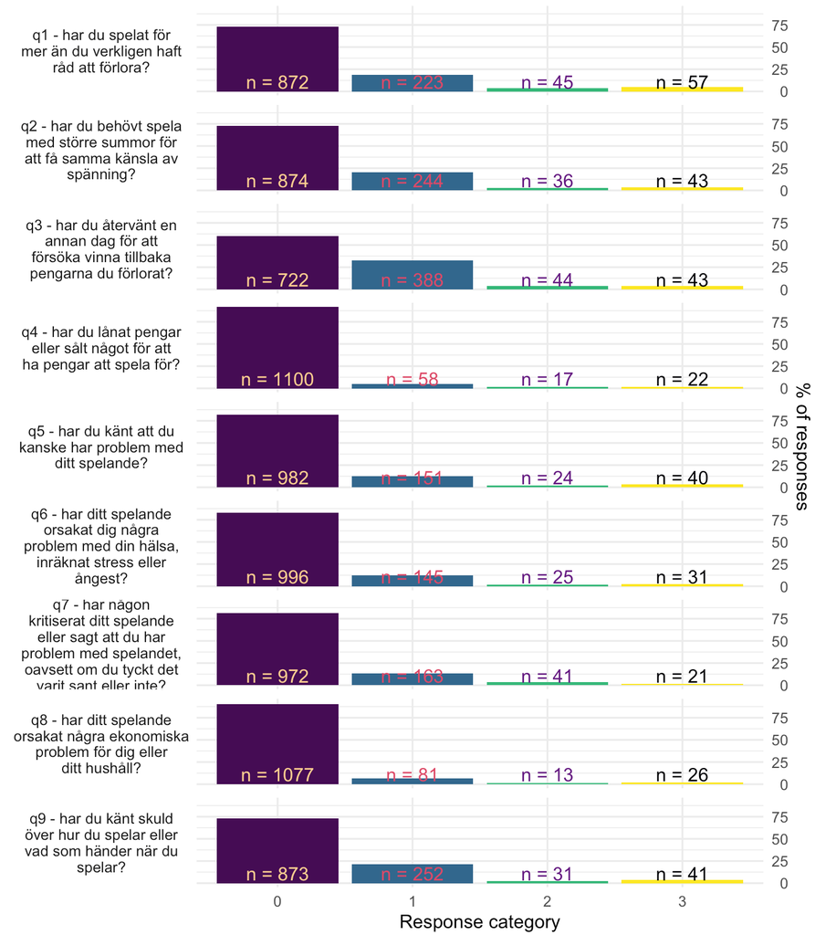

## Dimensionalitet

Samtliga analysmetoder visar på **multidimensionalitet**:

- Item 2 och 3 (delvis 1) är *underfit*
- Item 5, 6 och 8 är *overfit*, med flera lokala beroenden sinsemellan

**Tidigare föreslagen indelning i item 1–4 och 5–9 passar inte data.**

En bättre fungerande indelning:

**Faktor 1**: item 1–4, 7 och 9

beteenden och upplevelser

**Faktor 2**: item 5, 6 och 8

*problem* med spelande, hälsa och ekonomi

Analyserade som separata delskalor fungerar item fit väl för båda faktorerna i Swelogs-data. **Korrelation** mellan faktorerna: *r* = 0.51.

## Svarskategorier

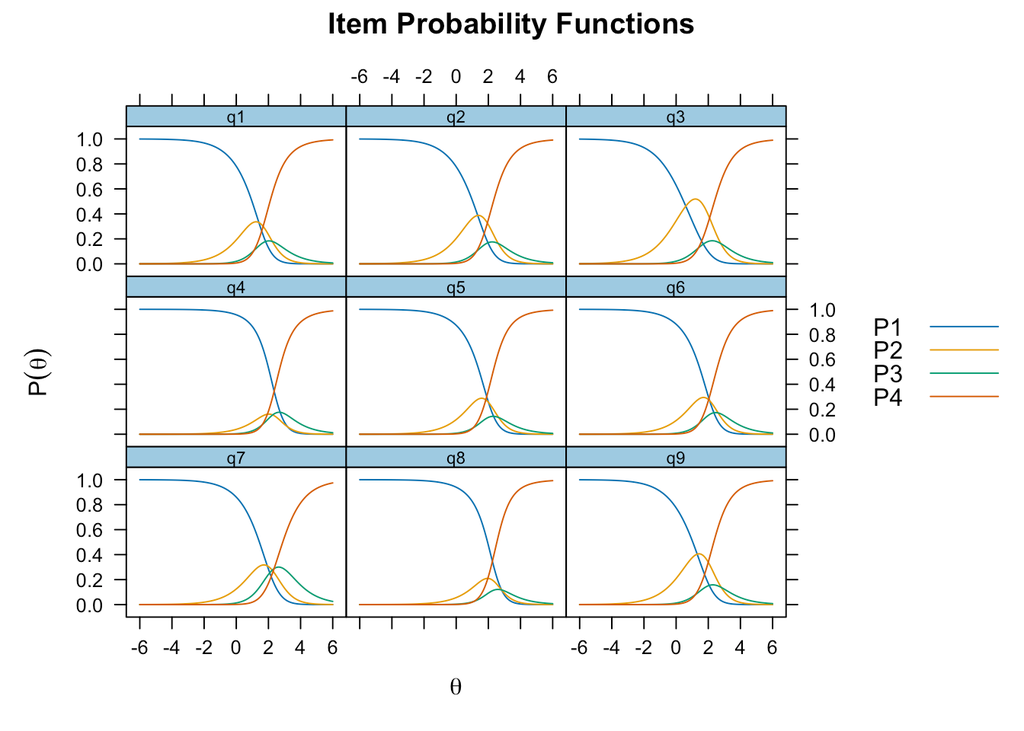

- **”Ofta” och ”Nästan alltid” är i princip identiska** för samtliga item, sett till sannolikhet givet den latenta variabeln
- Item 4, 5, 6 och 8 är i princip dikotoma

Svarskategoriernas utformning bör omarbetas inför ny datainsamling — kvalitativt **och** kvantitativt.

## Invarians

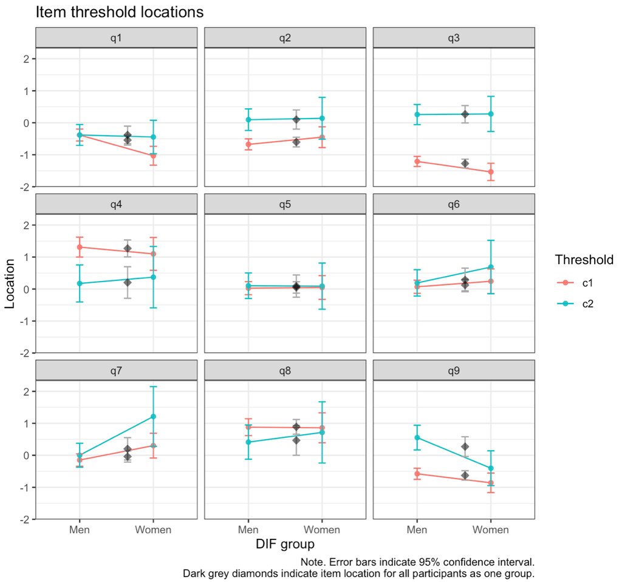

- Över tid (2015–2021): stabila i genomsnitt, men brokigare på tröskelnivå
- Vissa skillnader mellan kön
- De två högsta svarskategorierna har slagits samman i analyserna — för få svar i subgrupper

## Targeting

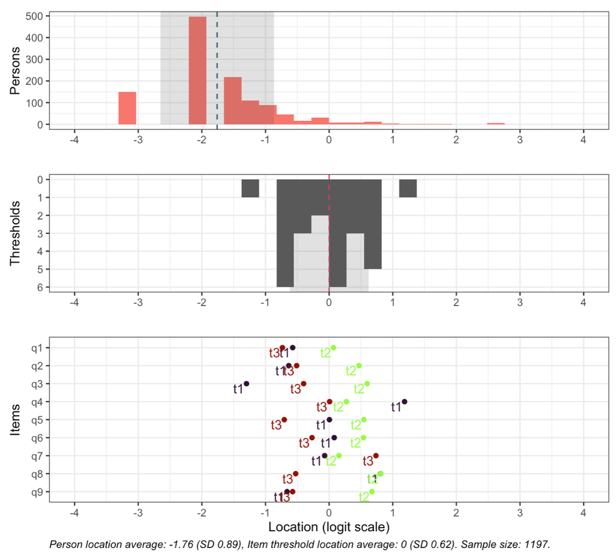

- Respondenternas medelvärde: **−1.76 logits**; items trösklar centrerade kring 0
- Frågorna mäter en **betydligt högre problemnivå** än där större delen av befolkningen befinner sig
- Mest information om respondenter med förhöjd risk — lite information i den lägre delen av skalan

## Två delskalor — targeting

**”PGSI-6”** (item 1–4, 7, 9)

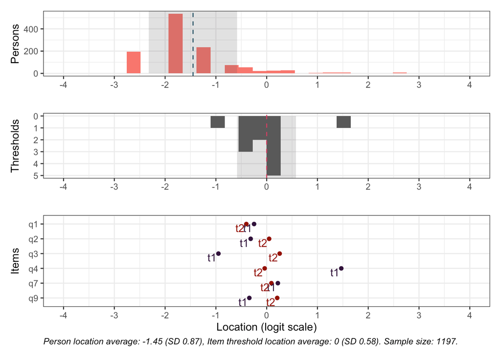

**”PGSI-3”** (item 5, 6, 8)

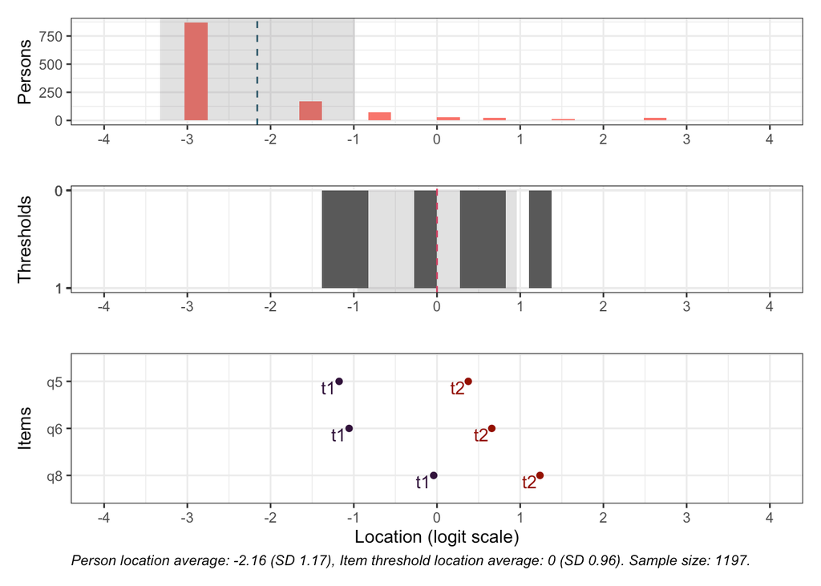

**Faktor 2**: inga oordnade trösklar efter sammanslagning. **Korrelation** F1 & F2 *r* = 0.51

## CFA: jämförelse med kanadensiska data

- Cooper & Marmurek (2023) använde tumregelsbaserade gränsvärden och bedömde att både 1- och 2-faktormodellen (item 1–4 / 5–9) passade data.
- Vår omanalys med **simuleringsbaserade gränsvärden** (DFI): *ingen* av modellerna passar — varken i deras data eller i Swelogs.
- Endast **”PGSI-6”** (item 1–4, 7, 9) med Swelogs-data uppvisar acceptabel modellpassning.

## CFA: jämförelse (2/2)

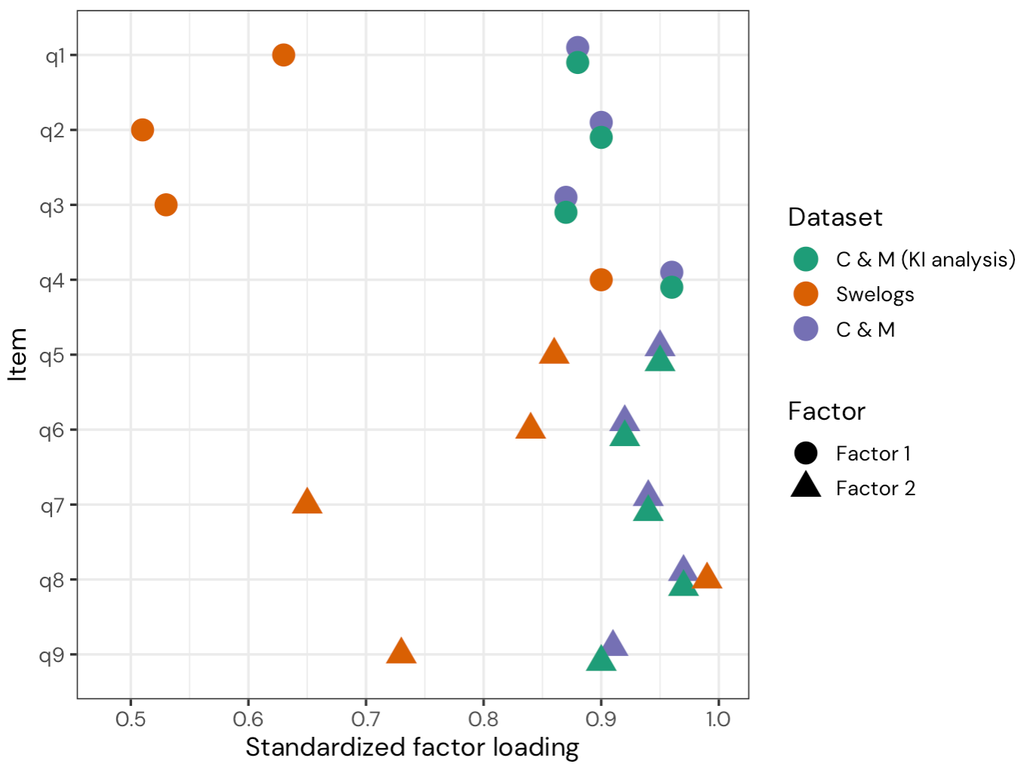

- Anmärkningsvärt stora skillnader i faktorladdningar mellan dataseten, särskilt item 1–3, 7 och 9.
- Samma mönster som item fit i Rasch-analyserna.

## Stödlinjen — en annan population

- 4941 respondenter (2021) — personer som söker stöd för spelproblem
- **Item 7 är starkt underfit**, även item 2 underfit; item 5, 6 och 8 overfit
- Ett stort antal lokala beroenden
- Vissa resultat skiljer sig från Swelogs — vi rekommenderar fördjupade analyser, gärna med data från flera årtal

USUF (2021) hade endast 156 respondenter med svar över noll — för låg statistisk power för säkra slutsatser, men mönstren liknar Swelogs (de två faktorerna fungerar).

## Item 7 — problematisk konstruktion

*”har **någon kritiserat** ditt spelande **eller sagt** att du har problem med spelandet, **oavsett om du tyckt det varit sant eller inte**?”*

- **Dubbla frågeställningar** — två olika saker i samma fråga
- **Villkorande bisats** — ”oavsett om…” gör frågan otydlig
- ”Kritiserat ditt spelande” kan tolkas som kritik av *hur* man spelar, snarare än *att* man spelar
- Bör omarbetas även om den fungerar acceptabelt psykometriskt i Swelogs

Folkhälsomyndighetens kognitiva intervjuer har även visat tolkningsproblem med **item 3** på grund av en inbyggd kausalitet.

## Vad betyder detta för summapoängen?

- **Svarskategorierna** fungerar inte som avsett → oklart vad en given summapoäng representerar, eftersom den kan bestå av många olika kombinationer av item-svar
- **Multidimensionalitet** → argument mot att summera samtliga nio item
- **Invarians**-problematik kring de lägsta trösklarna → kan påverka klassificering av respondenter olika för olika grupper

Vi rekommenderar att se över lämpligheten i att använda ordinala summapoäng för att klassificera individer i riskgrupper.

## Sammanfattning & vägen framåt

- PGSI-9 har **påtagliga psykometriska svagheter**: svarskategorier, multidimensionalitet, och viss invariansproblematik
- Rekommendationer kräver ett **tydligt definierat syfte & användningsområde**
- **Svarskategorierna** bör omarbetas och testas både kvalitativt och kvantitativt
- Vid revidering: **testekvivalering** gör det möjligt att samkalibrera gamla och nya item och översätta mätvärden mellan versioner
- För screening är lokala beroenden mindre problematiska — item kan i praktiken tolkas dikotomt

## Tack!

**Magnus Johansson, PhD**

**Kristoffer Magnusson, MD**

Department of Clinical Neuroscience

## Referenser

Christensen, Karl Bang, Svend Kreiner, och Mounir Mesbah, red. 2013. *Rasch models in health*. Applied mathematics series. ISTE ; John Wiley & Sons.

Christensen, Karl Bang, Guido Makransky, och Mike Horton. 2017. ”Critical Values for Yen’s Q3: Identification of Local Dependence in the Rasch Model Using Residual Correlations”. *Applied Psychological Measurement* 41 (3): 178–94. https://doi.org/10.1177/0146621616677520.

Cooper, Andrew, och Harvey H. C. Marmurek. 2023. ”Separating Behaviours and Adverse Consequences in the Problem Gambling Severity Index (PGSI): A Confirmatory Factor Analysis and Rasch Analysis”. *Journal of Gambling Studies*, advance online publication. https://doi.org/10.1007/s10899-023-10238-7.

James, Richard, Jane Tillsley, Lucy Hitcham, Chao Mou, HyeSeung Kim, och Richard Tunney. 2025. ”Disordered gambling, or dependence and consequences: A bifactor exploratory structural equation model analysis of the problem gambling severity index”. *Addiction Research and Theory* 33 (2): 122–34.

Johansson, Magnus. 2025. ”Detecting Item Misfit in Rasch Models”. *Educational Methods & Psychometrics* 3 (18). https://doi.org/10.61186/emp.2025.5.

McNeish, Daniel, och Melissa G. Wolf. 2024. ”Direct Discrepancy Dynamic Fit Index Cutoffs for Arbitrary Covariance Structure Models”. *Structural Equation Modeling: A Multidisciplinary Journal* 31 (5): 835–62. https://doi.org/10.1080/10705511.2024.2308005.

Müller, Marianne. 2020. ”Item fit statistics for Rasch analysis: can we trust them?” *Journal of Statistical Distributions and Applications* 7 (1): 5. https://doi.org/10.1186/s40488-020-00108-7.